# Prepare Migrate Input

Mary Fisher

8/12/2021- Last Run 2021-08-12

# Description

Prepare locus and sequencing information from Stacks files for the Migrate input files.

Migrate estimates effective population sizes and past migration rates between ‘n’ populations, and requires (1) loci with no or little missing data, and (2) the rad-tags, or sequences, for each locus and individual. To get this information, this script pulls from the final genepop file output from Stacks as well as the `sstacks` output file “XXX.matches.tsv” and the `ustacks` output file “XXX.tags.tsv”

Additional Resources: * [About Migrate](https://peterbeerli.com/migrate-html5/about.html) * [Stacks Manual](https://catchenlab.life.illinois.edu/stacks/manual/#ufiles)

# Part 1: Identify RAD loci for Migrate

## 1.1 Missing Data

Since Migrate was built for microsats, it doesn’t handle missing data well. So the first step is to determine how many - if any - of the RAD loci have zero missing data across 100% - 95% of individuals.

Read in the genotypes, from the .csv file in the data folder.

```r
genos <- read.csv(here::here("data", "genepop", "korea-pcod-final-filtered-migrants-removed-genotypes.csv")) %>%
  clean_names()
# View(genos)
```

Each row represents all of the genotypes for a particular individual, with each column a RAD locus. From here, count the number of 0s in each column to determine the number of individuals missing data for that locus.

```r
n_missing <- apply(genos[,-1],MARGIN=2,FUN=function(x){return(length(which(x==0)))})
missing_genos <- as.data.frame(n_missing)
```

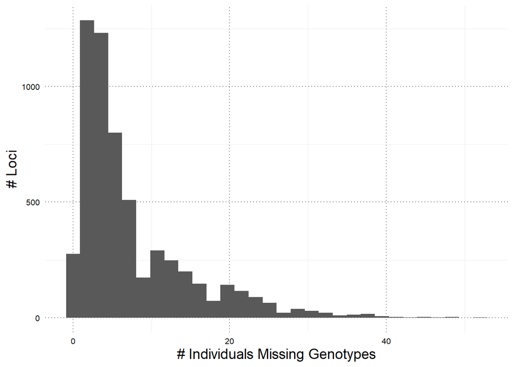

The following RAD loci have no missing genotypes:

```r
keep_loci <- rownames(dplyr::filter(missing_genos, n_missing==0))
keep_loci
```

```
##   [1] "x10112" "x10250" "x10319" "x1041"  "x10587" "x10589" "x10598" "x10753"
##   [9] "x10953" "x10997" "x11038" "x11047" "x11109" "x11154" "x11202" "x11220"
##  [17] "x11230" "x11276" "x11422" "x11539" "x11543" "x11549" "x11662" "x11677"
##  [25] "x11828" "x11950" "x1198"  "x11983" "x12061" "x12260" "x12372" "x12476"
##  [33] "x12508" "x12597" "x12742" "x12782" "x12800" "x12906" "x12977" "x1300"
##  [41] "x13040" "x13104" "x13128" "x13143" "x13154" "x13162" "x1322"  "x13236"
##  [49] "x13329" "x13364" "x13564" "x1361"  "x13674" "x14019" "x14056" "x14166"
##  [57] "x14168" "x14266" "x14309" "x14343" "x14703" "x14704" "x14874" "x14927"
##  [65] "x15043" "x15097" "x15124" "x15324" "x1547"  "x15493" "x15514" "x15571"
##  [73] "x1575"  "x15789" "x16015" "x1605"  "x16323" "x16489" "x16617" "x16669"
##  [81] "x1669"  "x1671"  "x16874" "x16893" "x1696"  "x1699"  "x17109" "x17199"
##  [89] "x17404" "x17731" "x17767" "x17935" "x17981" "x18050" "x18052" "x18156"
##  [97] "x18210" "x18233" "x1832"  "x18560" "x18626" "x18819" "x1885"  "x18943"
## [105] "x18968" "x19082" "x1911"  "x19262" "x19269" "x19342" "x19373" "x19413"
## [113] "x19467" "x19489" "x19505" "x19508" "x19524" "x19737" "x19791" "x19889"
```

[output cut: 20 more lines]

Which is a total of 276 RAD loci. Save the list of loci to a file…

```r
loci_out <- sapply(keep_loci, substring, 2)
write.csv(loci_out, here::here("data","migrate","RADloci_no_missing_data.csv"),row.names=FALSE)
```

… and the genotypes.

```r
genepop <- read.genepop(here::here("data","genepop","korea-pcod-final-filtered-migrants-removed.gen"))
```

```r
genepop_sub <- genepop[,loc=all_of(loci_out)]
write.csv(genepop_sub, here::here("data","migrate","genotypes_no_missing_data.gen"))
```

I’d like a larger pool of loci to pull from over multiple iterations, though.

## 1.2. Remove Individuals

#### **Individuals with many missing genotypes**

It may be possible to increase the number of loci without missing data by removing some “problem” individuals. Of the loci missing 1-2 genotypes, are there any individuals in common?

First, get the loci missing 1-2 genotypes.

```r
mg1 <- rownames(dplyr::filter(missing_genos, n_missing %in% c(1,2)))
mg1_genos <- dplyr::select(genos, c("sample_id", all_of(mg1)))
length(mg1)
```

```
## [1] 1287
```

Are there any individuals missing a bunch of those 1287 RAD loci?

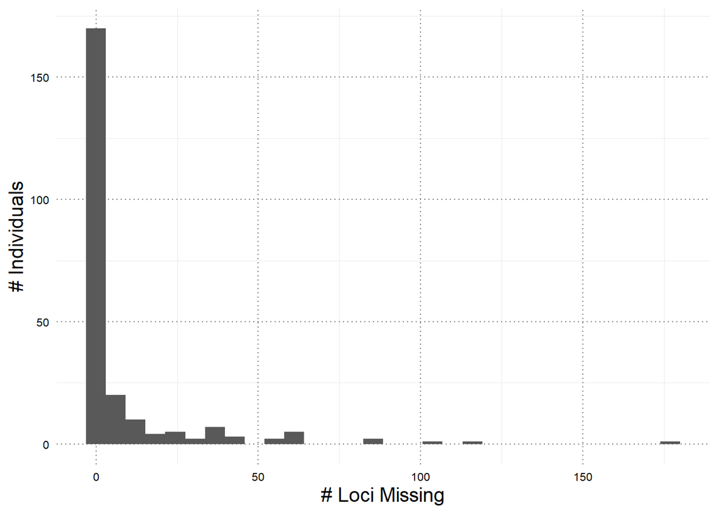

```r
mg1_individs <- as.data.frame(rowSums(mg1_genos[,-1]==0))
colnames(mg1_individs) <- c("n_loci_missing"); rownames(mg1_individs) <- mg1_genos[,1]
```

The individuals with over 50 / 1287 loci missing are:

|  | n_loci_missing |
| --- | --- |
| JB121807_35_2 | 54 |
| JB021108_39 | 58 |
| JB021108_28_2 | 177 |
| GEO020414_15_300 | 60 |
| GEO020414_29 | 60 |
| YS_121316_29 | 62 |
| YS_121316_19 | 103 |
| JUK07_17 | 60 |
| JUK07_22 | 53 |
| JUK07_25 | 85 |
| JUK07_28 | 88 |
| JUK07_10 | 113 |

Unfortunately Jukbyeon is heavily represented, and it’s the only population from the eastern coast. The individuals with over 75 / 1287 loci missing are:

|  | n_loci_missing |
| --- | --- |
| JB021108_28_2 | 177 |
| YS_121316_19 | 103 |
| JUK07_25 | 85 |
| JUK07_28 | 88 |
| JUK07_10 | 113 |

If I remove those individuals, does that change the number of loci with no missing data?

```r
genos2 <- genos %>%
  filter(!(sample_id %in% rownames(dplyr::filter(mg1_individs, n_loci_missing > 75))))

n_missing2 <- apply(genos2[,-1],MARGIN=2,FUN=function(x){return(length(which(x==0)))})
missing_genos2 <- as.data.frame(n_missing2)

keep_loci2 <- rownames(dplyr::filter(missing_genos2, n_missing==0))
length(keep_loci2)
```

```
## [1] 276
```

Ok, backing up to individuals with lots of missing data in the original data set, instead of just within the pool of loci with 1-2 missing genotypes.

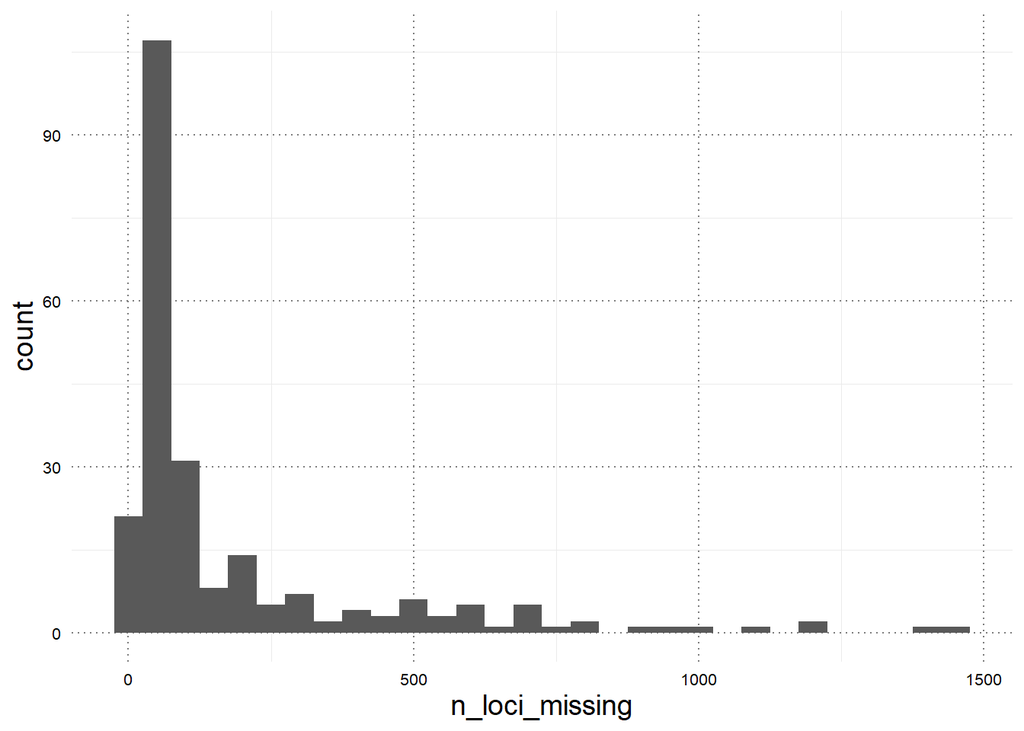

```r
mg2_individs <- as.data.frame(rowSums(genos[,-1]==0)); colnames(mg2_individs) <- c("n_loci_missing"); rownames(mg2_individs) <- genos[,1]
ggplot(mg2_individs, aes(x=n_loci_missing)) +
  geom_histogram()
```

The individuals with over 1000 loci missing are:

```
## [1] "JB121807_12_1" "JB121807_25"   "JB021108_38_1" "JB021108_28_2"
## [5] "YS_121316_19"  "JUK07_10"
```

Get rid of the individuals with over 1000 loci missing. Does this change the number of loci with no missing data?

```r
genos3 <- genos %>%
  filter(!(sample_id %in% rownames(dplyr::filter(mg2_individs, n_loci_missing > 1000))))

n_missing3 <- apply(genos3[,-1],MARGIN=2,FUN=function(x){return(length(which(x==0)))})
missing_genos3 <- as.data.frame(n_missing3)

keep_loci3 <- rownames(dplyr::filter(missing_genos3, n_missing==0))
length(keep_loci3)
```

```
## [1] 276
```

#### **Individuals with missing genotypes in common**

Instead of targeting individuals with high overall missing data, target individuals which have missing data at the same loci. To identify these individuals, I’m going to create a heatmap that shows the number of loci at which individuals have “shared zeros.”

The function that does this:

```r
shared_zeros <- function(x,y){
  # input x / y: single-row data frames with each column a locus, and values the genotypes
  # get the loci at which individual x has zeros
  x_zeros <- colnames(x)[which(x==0)]
  # get the loci at which individual y has zeros
  y_zeros <- colnames(y)[which(y==0)]
  # find intersection, score similarity
  sim <- sum(x_zeros %in% y_zeros)
  return(sim)
}
```

Fill in the matrix. **this is super inefficient, working on better fx than a for loop.**

```r
A <- matrix(data=0,nrow=dim(mg1_genos)[1], ncol=dim(mg1_genos)[1])
for(i in seq(1,dim(mg1_genos)[1])){
  for(j in seq(1,dim(mg1_genos)[1])){
    sim <- shared_zeros(x=mg1_genos[i,], y=mg1_genos[j,])
    A[i,j] <- sim
  }
}
```